# report

Dae-Yong Kim

2024-03-19

## 1.

### this exercise invovles the Auto data set studied in lab. Make sure that the missing values have been removed from the data.

#### (a) Which of the predictors are quantitative, and which are qualitatives?

```r
library(ISLR2)
data(Auto)
head(Auto)
```

```
##   mpg cylinders displacement horsepower weight acceleration year origin
## 1  18         8          307        130   3504         12.0   70      1
## 2  15         8          350        165   3693         11.5   70      1
## 3  18         8          318        150   3436         11.0   70      1
## 4  16         8          304        150   3433         12.0   70      1
## 5  17         8          302        140   3449         10.5   70      1
## 6  15         8          429        198   4341         10.0   70      1
##                        name
## 1 chevrolet chevelle malibu
## 2         buick skylark 320
## 3        plymouth satellite
## 4             amc rebel sst
## 5               ford torino
## 6          ford galaxie 500
```

First off, the list of predictors in the Auto data set is as follows. predictors_list=[“mpg”, “cylinders”, “displacement”, “horsepower”, “weight”, “acceleration”, “year”, “origin”, “name”

- quantitative : mpg, displacement, horsepower, weight, acceleration, year
- qualitative : cylinders, origin, name

#### (b) What is the range of each quantitative predictor? You can answer this using the range() function.

```r
range(Auto$mpg)
```

```
## [1]  9.0 46.6
```

```r
range(Auto$displacement)
```

```
## [1]  68 455
```

```r
range(Auto$horsepower)
```

```
## [1]  46 230
```

```r
range(Auto$weight)
```

```
## [1] 1613 5140
```

```r
range(Auto$acceleration)
```

```
## [1]  8.0 24.8
```

```r
range(Auto$year)
```

```
## [1] 70 82
```

#### (c) What is the mean and standard deviation of each quantitative predictor?

##### mpg

```r
mean_mpg = mean(Auto$mpg)
sd_mpg = sd(Auto$mpg)
print(sprintf("mean: %f, standard deviation: %f", mean_mpg, sd_mpg))
```

```
## [1] "mean: 23.445918, standard deviation: 7.805007"
```

##### displacement

```r
mean_displacement = mean(Auto$displacement)
sd_displacement = sd(Auto$displacement)
print(sprintf("mean: %f, standard deviation: %f", mean_displacement, sd_displacement))
```

```
## [1] "mean: 194.411990, standard deviation: 104.644004"
```

##### horsepower

```r
mean_horsepower = mean(Auto$horsepower)
sd_horsepower = sd(Auto$horsepower)
print(sprintf("mean: %f, standard deviation: %f", mean_horsepower, sd_horsepower))
```

```
## [1] "mean: 104.469388, standard deviation: 38.491160"
```

##### weight

```r
mean_weight = mean(Auto$weight)
sd_weight = sd(Auto$weight)
print(sprintf("mean: %f, standard deviation: %f", mean_weight, sd_weight))
```

```
## [1] "mean: 2977.584184, standard deviation: 849.402560"
```

##### acceleration

```r
mean_acc = mean(Auto$acceleration)
sd_acc = sd(Auto$acceleration)
print(sprintf("mean: %f, standard deviation: %f", mean_acc, sd_acc))
```

```
## [1] "mean: 15.541327, standard deviation: 2.758864"
```

##### year

```r
mean_year = mean(Auto$year)
sd_year = sd(Auto$year)
print(sprintf("mean: %f, standard deviation: %f", mean_year, sd_year))
```

```
## [1] "mean: 75.979592, standard deviation: 3.683737"
```

```r
new_auto = Auto[-c(10, 85), ]
new_auto$name = as.numeric(new_auto$name)
means = colMeans(new_auto, na.rm = TRUE)

ranges = apply(new_auto, 2, range)
means = colMeans(new_auto, na.rm = TRUE )
sds = apply(new_auto, 2, sd)
```

##### the range of each predictor in the subset of the data that remains

```r
ranges
```

```
##       mpg cylinders displacement horsepower weight acceleration year origin
## [1,]  9.0         3           68         46   1613          8.0   70      1
## [2,] 46.6         8          455        230   5140         24.8   82      3
##      name
## [1,]    1
## [2,]  304
```

##### mean of each predictor in the subset of the data that remains

```r
means
```

```
##          mpg    cylinders displacement   horsepower       weight acceleration
##    23.494359     5.458974   193.511538   104.069231  2972.469231    15.565897
##         year       origin         name
##    76.002564     1.579487   149.043590
```

##### standard deviation of each predictor in the subset of the data that remains

```r
sds
```

```
##          mpg    cylinders displacement   horsepower       weight acceleration
##    7.7951978    1.7004790  104.1406899   38.1763305  848.5120670    2.7396716
##         year       origin         name
##    3.6775556    0.8065221   89.2329533
```

#### (e) Using the full data set, investigate the predictors graphcially, using scatterplots or other tools of your choice. Create some plots highlighting the relationships among the predictors. Comment on your findings.

##### e-1) relationship between displacement and mpg

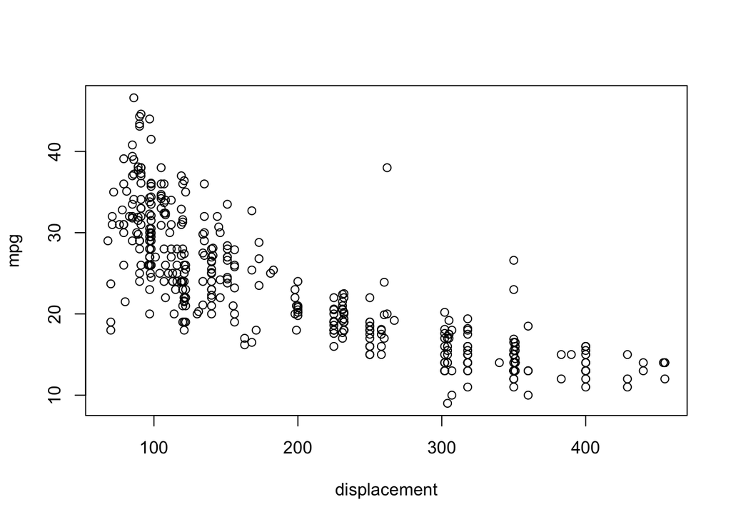

```r
dis = Auto$displacement
mpg = Auto$mpg

plot(dis, mpg, xlab="displacement", ylab="mpg")
```

As displacement increases, there is a tendency for mpg to decrease. Displacement and mpg have a negative correlation.

##### e-2) relationship between displacement and horsepower

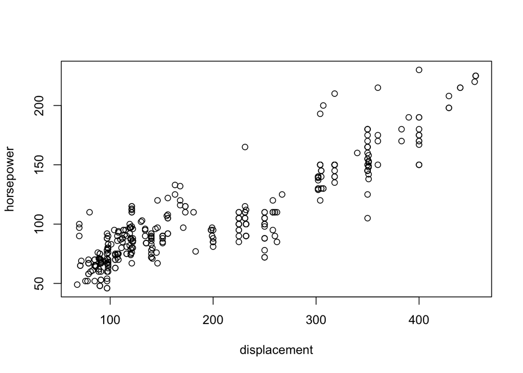

```r
dis = Auto$displacement
horsepower = Auto$horsepower

plot(dis, horsepower, xlab="displacement", ylab="horsepower")
```

When displacement increases, we can observe an increase in horsepower as well. These two variables have a positive correlation.